# Исследование по разработке стратегии взаимодействия с клиентами сети фитнес-центров

Задачи исследования - на основе данных о посетителях:

1. спрогнозировать их отток и проанализировать основные признаки, наиболее сильно на него влияющие;
2. сформировать типичные портреты клиентов;
3. разработать рекомендации по повышению качества работы с клиентами.

Навигация:

- Описание и задачи
- Исследовательский анализ данных
  - Распределение признаков
  - Корреляции признаков
- Модель прогнозирования оттока клиентов
- Кластеризация клиентов
- Выводы и рекомендации

Импортируем необходимые библиотеки.

```python
import pandas as pd
import numpy as np
import phik

import matplotlib
import matplotlib.pyplot as plt
import seaborn as sns

from sklearn.model_selection import train_test_split
from sklearn.linear_model import LogisticRegression
from sklearn.ensemble import RandomForestClassifier
from sklearn.metrics import accuracy_score, precision_score, recall_score

from sklearn.preprocessing import StandardScaler

from scipy.cluster.hierarchy import dendrogram, linkage
from sklearn.cluster import KMeans
```

Установим параметры визуализации.

```python
#%config InlineBackend.figure_format = 'retina'
matplotlib.style.use('bmh')
```

## Исследовательский анализ данных

к навигации

Загрузим данные и ознакомимся с ними.

```python
local_path = r'C:\Практикум\Учебные проекты\13 Основы машинного обучения\\'
cloud_path = r'Путь к облачному хранилищу'

def get_data(file_name):
    try:
        data = pd.read_csv(local_path + file_name)
        print('Датасет {0} загружен локально.'.format(file_name))
    except:
        data = pd.read_csv(cloud_path + file_name)
        print('Датасет {0} загружен из облака.'.format(file_name))
    return data

data = get_data('gym_churn.csv')
```

```
Датасет gym_churn.csv загружен локально.
```

```python
#data.info()
#data.head()
```

Все данные (в том числе, категориальные) представлены в числовом формате, пропуски отсутствуют.

```python
data.duplicated().sum()
```

```
0
```

Явных дубликатов нет.

Предобработка не требуется.

### Распределение признаков

к навигации

Посмотрим на средние значения параметров для оттекших и оставшихся клиентов.

```python
data.groupby('Churn').agg('mean')
```

| Churn | gender | Near_Location | Partner | Promo_friends | Phone | Contract_period | Group_visits | Age | Avg_additional_charges_total | Month_to_end_contract | Lifetime | Avg_class_frequency_total | Avg_class_frequency_current_month |
| --- | --- | --- | --- | --- | --- | --- | --- | --- | --- | --- | --- | --- | --- |
| 0 | 0.510037 | 0.873086 | 0.534195 | 0.353522 | 0.903709 | 5.747193 | 0.464103 | 29.976523 | 158.445715 | 5.283089 | 4.711807 | 2.024876 | 2.027882 |
| 1 | 0.510839 | 0.768143 | 0.355325 | 0.183789 | 0.902922 | 1.728558 | 0.268615 | 26.989632 | 115.082899 | 1.662582 | 0.990575 | 1.474995 | 1.044546 |

Некоторые значения (такие как - пол, наличие контактного телефона, etc.) практически равны. Некоторые (например, длительность абонемента) заметно отличаются. Очевидно, что факторы влияют на отток клиентов по-разному.

Построим графики распределения каждого параметра для обеих групп.

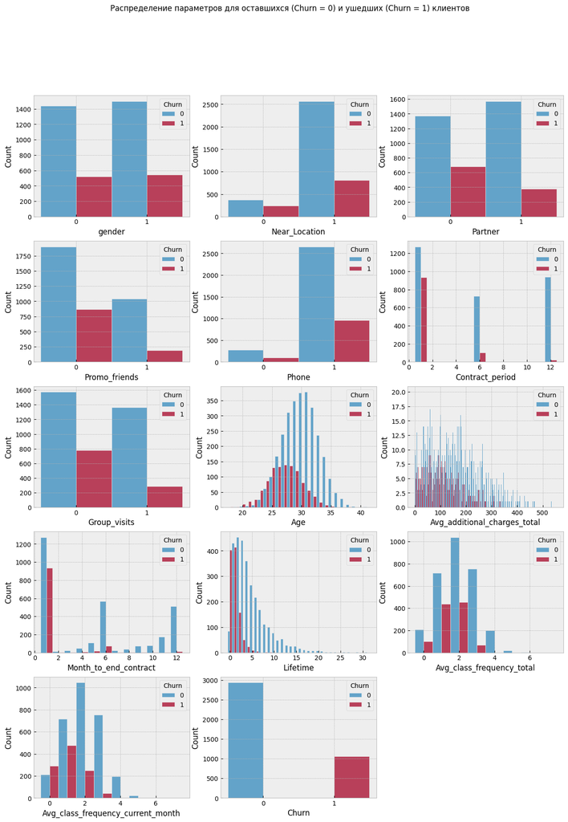

```python
fig = plt.figure(figsize=(15,20))
fig.suptitle("Распределение параметров для оставшихся (Churn = 0) и ушедших (Churn = 1) клиентов")
for i, column in enumerate(data.columns):
    ax = fig.add_subplot(5, 3, i + 1)
    if data[column].nunique() == 2:
        ax.set_xticks([0, 1]) # избавимся от дробей в категориальных значениях
    sns.histplot(data, x=column, hue='Churn', multiple='dodge', discrete=True)
```

- Распределение (соотношение) признаков 'gender' и 'Phone' в группах оттекших и оставшихся примерно одинаково. Вероятно, эти признаки не влияют на отток.
- Среди оставшихся заметно больше доля живущих/работающих рядом; работающих в организации-партнере; пришедших по рекомендации друзей; посещающих групповые занятия.
- Ощутима разница между группами по признаку 'Contract_period'. Соотношение оставшихся/ушедших для 1-месячного договора: 4/3, 6-месячного: 7/1, 12-месячного: 37/1. Видимо, срок контракта сильно влияет на целевой признак.
- Распределение возраста в обеих группах похоже на нормальное. Аномалий не видно. Для ушедших распределение смещено влево, в сторону молодости.
- Распределение параметра 'Month_to_end_contract' логично согласуется с распределением 'Contract_period'.
- Гистограмма признака 'Lifetime' похожа на распределение Пуассона. Аномалий не видно. У ушедших этот параметр ощутимо ниже.
- Распределения 'Avg_class_frequency_total' и 'Avg_class_frequency_current_month' похожи на смещенные влево нормальные. Для второго признака степень смещения ушедших заметнее. Видимо, перед тем как уйти, они начинают ходить реже. Виден пик в районе нуля - те, кто купили абонемент и не ходят. Любопытно, что на первом графике доля неходящих оставшихся больше, а на втором - меньше неходящих и ушедших.

### Корреляции признаков между собой и целевой переменной.

к навигации

Построим тепловую карту корреляций для категориальных переменных (phik_matrix).

```
interval columns not set, guessing: ['gender', 'Near_Location', 'Partner', 'Promo_friends', 'Phone', 'Group_visits', 'Churn']
```

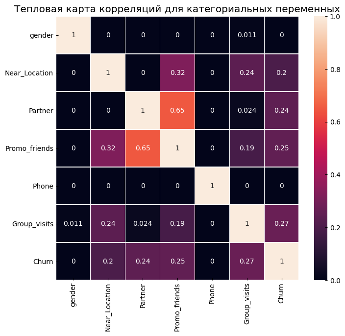

```python
fig, ax = plt.subplots(figsize=(8,7))
sns.heatmap(data[['gender',
                  'Near_Location',
                  'Partner',
                  'Promo_friends',
                  'Phone',
                  'Group_visits',
                  'Churn']].phik_matrix(), annot=True, linewidth=.1) \
   .set(title='Тепловая карта корреляций для категориальных переменных')
plt.show()
```

- Работа в компании-партнере и использование промокода при записи показывают умеренную корреляцию между собой.
- Ни один из параметров не показывает даже умеренной связи с целевой переменной.
- Пол и наличие контактных данных вообще никак ни с чем не коррелирут.

Построим тепловую карту корреляций Пирсона/Спирмана для количественных переменных.

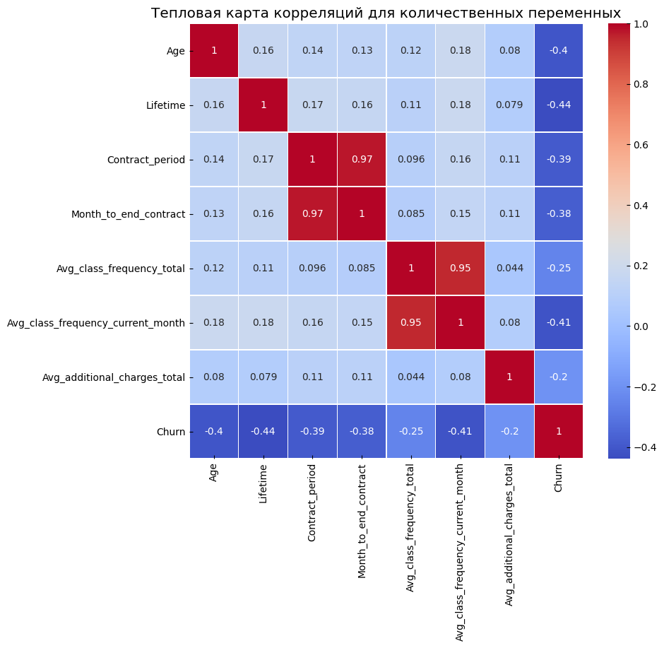

```python
fig, ax = plt.subplots(figsize=(9,8))
sns.heatmap(data[['Age',
                  'Lifetime',
                  'Contract_period',
                  'Month_to_end_contract',
                  'Avg_class_frequency_total',
                  'Avg_class_frequency_current_month',
                  'Avg_additional_charges_total',
                  'Churn']].corr(), annot=True, linewidth=.1, cmap='coolwarm') \
   .set(title='Тепловая карта корреляций для количественных переменных')
plt.show()
```

Очень сильную положительную корреляцию между собой демонстрируют:

- длительность абонемента и срок до его окончания;
- средняя частота посещений за все время и за последний месяц.  
  Довольно логично.  
  Остальные факторы слабо (или очень слабо) положительно коррелируют друг с другом.

Некоторые параметры умеренно отрицательно коррелируют с целевой переменной. Вероятность оттока тем меньше чем:

- старше клиент (понимание приходит с опытом);
- больше времени прошло с момента первого обращения в фитнес-центр (постоянные клиенты, без иронии - такие постоянные!);
- длиннее абонемент и
- дольше до его окончания (заплатил - ходи!);
- чаще клиент посещал занятия в последний месяц (бросают поэтапно, а не в один момент).  
  Средняя посещаемость за весь срок и суммарная побочная выручка не сильно влияют на отток (-0.25 и -0.2).

## Модель прогнозирования оттока клиентов

к навигации

Обучим несколько моделей прогнозирования отткока клиентов и сравним результаты их предсказательной способности, используя метрики Accuracy, Precision и Recall. Обочим модели:

- методами логистической регрессии и случайного леса;
- на сырых и очищенных данных;
- на сырых и стандартизированных данных.  
  (всего - восемь комбинаций)

Объявим функцию,

- разбивающую данные на обучающую и тестовую выборки,
- стандартизирующую данные,
- обучающую модель
- и получающую интересующие нас метрики.

```python
def get_models_n_metrics(data, scaled, method, name):

    # Разобъем данные на обучающую и валидационную выборки в соотношении 3/1:
    X = data.drop('Churn', axis=1)
    y = data['Churn']
    X_train, X_test, y_train, y_test = train_test_split(X, y, test_size=0.25, random_state=0)

    # Стандартизируем данные:
    if scaled == True:
        ss = StandardScaler()
        X_train = ss.fit_transform(X_train)
        X_test = ss.transform(X_test)

    # Обучим модель:
    model = method
    model.fit(X_train, y_train)
    prediction = model.predict(X_test)

    # Получим метрики Accuracy, Precision и Recall:
    accuracy = accuracy_score(y_test, prediction)
    precision = precision_score (y_test, prediction)
    recall = recall_score (y_test, prediction)

    result = pd.DataFrame(data={'accuracy': accuracy, 'precision': precision, 'recall': recall}, index=name)
    return result
```

Создадим датафрейм, из которого исключим сильно коррелирующие между собой признаки, чтобы избавиться от мультиколлениарности, а также - параметры, не влияющие на целевую переменную.

```python
r_data = data
c_data = data.drop(['Month_to_end_contract', 'Avg_class_frequency_total', 'gender', 'Phone'], axis=1)
```

Получим таблицу с показателями метрик для каждого из вариантов моделей.

```python
metrics = pd.DataFrame(columns = ['accuracy', 'precision', 'recall'])

for key, value in {'Логистическая регрессия, ': LogisticRegression(solver='liblinear'),
                   'Случайный лес, ': RandomForestClassifier()}.items():
    name_1 = key
    method = value
    for key, value in {'сырые ': r_data, 'очищенные ': c_data}.items():
        name_2 = name_1 + key
        data = value
        for key, value in {'стандартизированные данные': True, 'нестандартизированные данные': False}.items():
            name = name_2 + key
            scaled = value
            metrics = metrics.append(get_models_n_metrics(data, scaled, method, [name]))

# Добавим поле со средним значением:
metrics['avg_metrics'] = metrics.mean(axis=1)
```

Построим тепловую карту сравнительной таблицы.

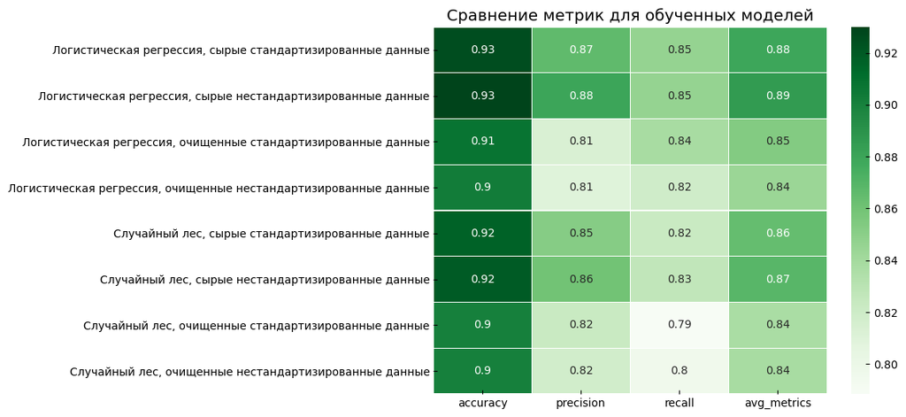

```python
fig, ax = plt.subplots(figsize=(8,6))
sns.heatmap(metrics, annot=True, linewidth=.1, cmap='Greens') \
   .set(title='Сравнение метрик для обученных моделей')
plt.show()
```

- Очистка данных негативно отразилась на всех метриках.
- Стандартизация почти не повлияла на результаты.
- Метод логистической регрессии показал себя немного лучше по количеству правильных ответов, точности и полноте.
- Все модели продемонстрировали сравнимые хорошие показатели.  
  Результаты теста могут различаться при ином разбиении на выборки.

## Кластеризация клиентов

к навигации

Построим дендрограмму, которая поможет определить количество кластеров, осуществим кластеризацию, и постараемся выделить ключевые признаки для каждого кластера.

Исключим никак ни с чем не коррелирующие параметры.

```python
data = r_data.drop(['gender', 'Phone'], axis=1)
```

Обучим модель на генеральной выборке без столбца с оттоком и стандартизируем данные.

```python
X = data.drop('Churn', axis=1)
scaler = StandardScaler()
X_st = scaler.fit_transform(X)
```

Построим дендрограмму.

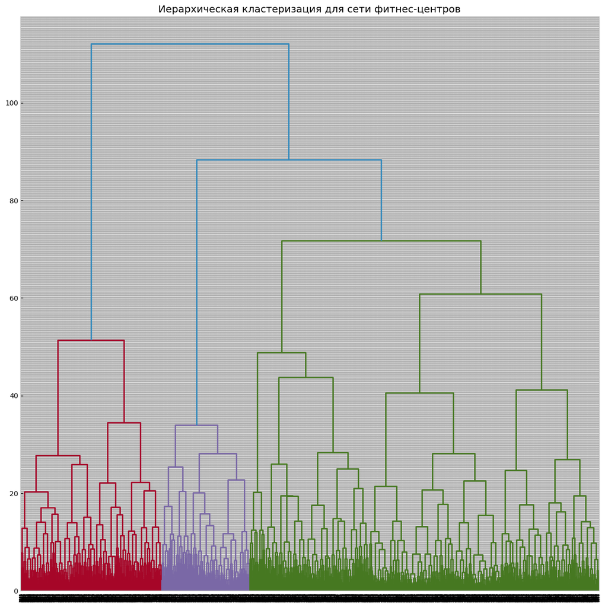

```python
linked = linkage(X_st, method = 'ward')
plt.figure(figsize=(15, 15))
dendrogram(linked, orientation='top')
plt.title('Иерархическая кластеризация для сети фитнес-центров')
plt.show()
```

Основываясь на уровне ветвения и размере, кажется целесообразным выделить 5 кластеров, а не 3, как предлагает алгоритм.

```python
km = KMeans(n_clusters=5, random_state=0)
labels = km.fit_predict(X_st)
```

Добавим к датафрейму столбец с номером кластера и посмотрим на сгруппированные данные.

```python
data['claster'] = labels
data.groupby('claster').agg('mean').sort_values('Churn').round(2)
```

| claster | Near_Location | Partner | Promo_friends | Contract_period | Group_visits | Age | Avg_additional_charges_total | Month_to_end_contract | Lifetime | Avg_class_frequency_total | Avg_class_frequency_current_month | Churn |
| --- | --- | --- | --- | --- | --- | --- | --- | --- | --- | --- | --- | --- |
| 3 | 0.94 | 0.74 | 0.49 | 11.91 | 0.55 | 29.91 | 164.41 | 10.91 | 4.68 | 1.99 | 1.98 | 0.02 |
| 1 | 0.97 | 0.27 | 0.09 | 2.93 | 0.47 | 30.25 | 163.54 | 2.69 | 5.23 | 2.90 | 2.90 | 0.06 |
| 0 | 1.00 | 0.82 | 1.00 | 3.14 | 0.45 | 29.22 | 141.79 | 2.90 | 3.73 | 1.75 | 1.64 | 0.25 |
| 4 | 0.00 | 0.47 | 0.08 | 2.21 | 0.22 | 28.47 | 133.48 | 2.08 | 2.77 | 1.65 | 1.46 | 0.45 |
| 2 | 1.00 | 0.24 | 0.02 | 1.96 | 0.33 | 28.19 | 130.88 | 1.88 | 2.38 | 1.29 | 1.05 | 0.53 |

Значения в столбцах отличаются, можно выделить характерные черты для каждого кластера.  
Исключение - возраст. Исключим столбец 'Age' и пересоберем кластеры.

```python
data_1 = r_data.drop(['gender', 'Phone', 'Age'], axis=1)
X_1 = data_1.drop('Churn', axis=1)

X_st_1 = scaler.fit_transform(X_1)

km = KMeans(n_clusters=5, random_state=0)
labels_1 = km.fit_predict(X_st_1)

data_1['claster'] = labels_1

clasters = data_1.groupby('claster').agg('mean').sort_values('Churn')
```

```python
clasters.round(2)
```

| claster | Near_Location | Partner | Promo_friends | Contract_period | Group_visits | Avg_additional_charges_total | Month_to_end_contract | Lifetime | Avg_class_frequency_total | Avg_class_frequency_current_month | Churn |
| --- | --- | --- | --- | --- | --- | --- | --- | --- | --- | --- | --- |
| 1 | 0.94 | 0.74 | 0.49 | 11.90 | 0.55 | 164.87 | 10.90 | 4.70 | 1.99 | 1.98 | 0.02 |
| 4 | 0.97 | 0.25 | 0.08 | 2.89 | 0.47 | 161.47 | 2.65 | 5.13 | 2.89 | 2.89 | 0.07 |
| 2 | 1.00 | 0.80 | 1.00 | 3.12 | 0.45 | 140.85 | 2.89 | 3.66 | 1.75 | 1.64 | 0.25 |
| 0 | 0.00 | 0.47 | 0.08 | 2.18 | 0.21 | 133.56 | 2.04 | 2.77 | 1.66 | 1.47 | 0.45 |
| 3 | 1.00 | 0.25 | 0.01 | 1.95 | 0.33 | 131.69 | 1.86 | 2.41 | 1.27 | 1.03 | 0.52 |

Средние значения параметров не сильно изменились (хотя, заранее мы этого не знали и шаг кажется оправданным).  
Для упрощения анализа ранжируем распределение значений признаков от 1-го до 10-ти, где единице соответствует минимальное значение и построим тепловую карту.

```python
n = 10
group_names = list(range(1, n+1))
for column in clasters.columns:
    clasters[column] = pd.cut(clasters[column], bins = n, labels=group_names)
clasters = clasters.astype('int')
```

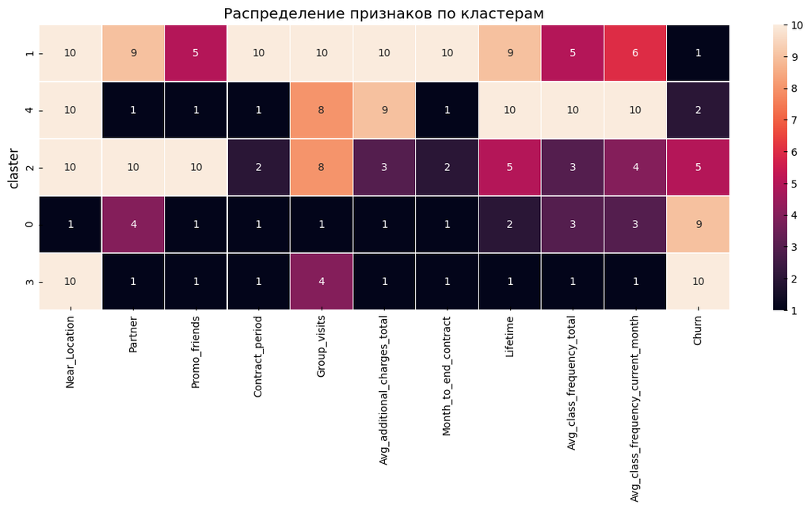

```python
fig, ax = plt.subplots(figsize=(15,5))
sns.heatmap(clasters, linewidth=.1, annot=True) \
   .set(title='Распределение признаков по кластерам')
plt.show()
```

Расположим кластеры в порядке увеличения вероятности оттока и выделим характерные черты:

1. Кластер "1": С большой вероятностью - сотрудник компании-партнера и/или использовавший промокод при оплате первого абонемента, с очень долгим контрактом. Постоянный клиент. Ходит два раза в неделю, не редко посещает групповые занятия. Вероятность оттока - около 2%.
2. Кластер "4": Характерная черта - максимальная среди всех кластеров частота посещений - 3 раза в неделю, при сравнительно небольшом сроке контракта. Также - постоянный клиент. Вероятность оттока - 7%.
3. Кластер "2": Использовавший промокод сотрудник компании-партнера. Почти все стальные показатели близки к средним. Вероятность оттока - 25%.
4. Кластер "0": Далеко живущие. Ходят полтора раза в неделю, и этот показатель падает. Почти не посещают групповых занятий. Вроятность оттока 45%.
5. Кластер "3": Живут рядом, но ходят редко и имеют краткосрочные контракты. Возможно - зашли попробовать, но не очень понравилось. Уходят в более чем половине случаев.

## Выводы и рекомендации

к навигации

В ходе предварительного анализа данных выяснилось, что предобработка не требуется.  
Построение тепловых карт корреляций показало неравнозначное влияние факторов на целевую переменную, а также, на взаимосвязь параметров между собой.  
В качестве метода разбиения на обучающую и валидационную выборки был выбран случайный метод, т.к. данные не содержат временных рядов.  
Были обучены и протестированы две модели прогнозирования оттока клиентов. Использовался алгоритм логической регрессии и случайный лес. Обе модели показали высокое значение метрик Accuracy, Precision и Recall.  
Удалось разбить клиентов на группы с помощью алгоритма кластеризации. Ниже представлены маркетинговые рекомендации, как по каждой группе, так и общие.

- "1". Группа клиентов с долгосрочным контрактом не требует внимания прямо сейчас, но, возможно, есть смысл постоянно поддерживать их контракт долгим. Например, предлагая льготные условия пролонгации. И чем заранее, тем льготнее.
- "4". Данная группа, вероятно, не требует дополнительных трат маркетингового бюджета, однако, имеет смысл провести дополнительное исследование и выявить факторы, которые сильнее влияют на отток в этой группе.
- "2". За исключением короткого абонемента и довольно большой вероятностью оттока, эта группа близка по характеристикам к первой. Возможно, жесткая, но действенная мера - ограничение минимального срока договора для сотрудников компаний-партнеров - могла бы способствовать переходу этого типа клиентов в первый кластер.
- "0". Вряд ли что-либо возможно сделать с основным показателем для этой группы - расстоянием от работы или дома до фитнес-центра, однако, редкость посещения групповых занятий (что, скорее - следствие) подвластна влиянию. Возможно, если предложить особые условия посещения таких занятий, клиенты из этой группы найдут себе фитнес-друзей, будут чаще и с большим интересом ходить в фитнес-центр, что может снизить показатель оттока.
- "3". Пришли попробовать, но не понравилось. Нужно сделать так, чтобы понравилось. В отличие от предыдущей группы, на эту, кажется, проще повлиять маркетинговым способом. Можно детально поработать с такими клиентами, провести, например, анкетирование, и выяснить, чем их можно заинтересовать.

Для всех групп: кажется, самым влиятельным, и, в то же время, подверженным влиянию фактором является наличие действующего долгосрочного договора. Имеет смысл детально проработать стратегию мотивирования клиентов к заключению такого типа контрактов.